# TFM melanoma - Descarga y preparación inicial de TCGA-SKCM

Sonia

2026-03-06

# 1 Primer chunk: opciones globales

```r
# Configuración global de los chunks de R Markdown.
# echo = TRUE hace que se vea el código en el documento final.
# warning = FALSE oculta avisos para que el informe quede más limpio.
# message = TRUE muestra mensajes de carga/descarga útiles en esta fase.
knitr::opts_chunk$set(
  echo = TRUE,
  warning = FALSE,
  message = TRUE
)
```

# 2 Segundo chunk: instalación de paquetes

```r
# Si BiocManager no está instalado, lo instalamos.
# BiocManager es el gestor de paquetes de Bioconductor,
# donde está TCGAbiolinks.
if (!requireNamespace("BiocManager", quietly = TRUE)) {
  install.packages("BiocManager")
}

# Lista de paquetes de Bioconductor que vamos a necesitar.
# TCGAbiolinks: descarga y manejo de datos TCGA/GDC.
# SummarizedExperiment: estructura de datos habitual para expresión génica.
paquetes_bioc <- c("TCGAbiolinks", "SummarizedExperiment")

# Lista de paquetes CRAN para manipulación y visualización.
# dplyr/tibble/readr/stringr: limpieza y manejo de datos.
# ggplot2: visualización.
paquetes_cran <- c("dplyr", "tibble", "readr", "stringr", "ggplot2")

# Instalamos cada paquete de Bioconductor solo si no está ya instalado.
for (p in paquetes_bioc) {
  if (!requireNamespace(p, quietly = TRUE)) {
    BiocManager::install(p, ask = FALSE, update = FALSE)
  }
}

# Instalamos cada paquete de CRAN solo si no está ya instalado.
for (p in paquetes_cran) {
  if (!requireNamespace(p, quietly = TRUE)) {
    install.packages(p)
  }
}
```

# 3 Tercer chunk: cargar librerías

Prepara el entorno de trabajo. Así, el script puede ejecutarse en cualquier ordenador aunque aún no tengas los paquetes instalados.

```r
# Cargamos las librerías que vamos a usar en el resto del documento.
library(TCGAbiolinks)
library(SummarizedExperiment)
library(dplyr)
```

```r
library(tibble)
library(readr)
library(stringr)
library(ggplot2)
```

### 3.0.1 Qué hace este bloque

Activa los paquetes instalados para poder usar sus funciones.

# 4 Cuarto chunk: crear carpetas de trabajo

Esto te ordena el proyecto desde el principio. Esto es muy importante para que luego el TFM sea reproducible.

```r
# Creamos carpetas para mantener el proyecto ordenado.
# data_raw: archivos descargados sin procesar.
# data_processed: archivos ya limpios o preparados.
# results: tablas de resultados.
# figures: gráficos.
dir.create("data_raw", showWarnings = FALSE)
dir.create("data_processed", showWarnings = FALSE)
dir.create("results", showWarnings = FALSE)
dir.create("figures", showWarnings = FALSE)
```

# 5 Quinto chunk: descargar datos clínicos

Descarga la **tabla clínica** del melanoma TCGA y la guarda en disco.  
Esto te servirá para construir variables como:

- edad,
- sexo,
- estado vital,
- tiempo de seguimiento,
- estadio.

```r
# Descargamos la información clínica del proyecto TCGA-SKCM.
# project = "TCGA-SKCM" indica que trabajamos con melanoma cutáneo.
# type = "clinical" pide la tabla clínica del proyecto.
clinical_tcga <- GDCquery_clinic(
  project = "TCGA-SKCM",
  type = "clinical"
)

# Mostramos dimensiones del dataset:
# número de filas (pacientes/registros) y columnas (variables clínicas).
dim(clinical_tcga)
```

```
## [1] 470  90
```

```r
# Mostramos los nombres de las columnas para ver qué variables tenemos.
colnames(clinical_tcga)
```

```
##  [1] "project"
##  [2] "submitter_id"
##  [3] "morphology"
##  [4] "days_to_diagnosis"
##  [5] "created_datetime"
##  [6] "tissue_or_organ_of_origin"
##  [7] "age_at_diagnosis"
##  [8] "primary_diagnosis"
##  [9] "classification_of_tumor"
## [10] "updated_datetime"
## [11] "diagnosis_id"
## [12] "icd_10_code"
## [13] "site_of_resection_or_biopsy"
## [14] "state"
## [15] "prior_treatment"
```

[output cut: 75 more lines]

```r
# Guardamos la tabla clínica cruda en CSV para poder consultarla fuera de R.
write_csv(clinical_tcga, "data_raw/tcga_skcm_clinical.csv")
```

# 6 # EDA clínico (TCGA melanoma)

Te ayudará a responder estas preguntas:

¿Cuántos pacientes fallecieron?

¿Cuántos están vivos?

¿Cuántos tienen estadio informado?

¿Cuántos NA hay en las variables clave?

Eso es muy importante antes de construir el dataset final.

- **1. Dimensión del dataset**

```r
dim(clinical_tcga)
```

```
## [1] 470  90
```

El dataset clínico TCGA-SKCM contiene 470 pacientes y 90 variables clínicas que describen características demográficas, tumorales, pronósticas y de tratamiento.

- **2. Estructura del dataset**

Esto permite identificar:

variables categóricas

variables numéricas

variables de fecha

identificadores de paciente

```r
glimpse(clinical_tcga)
```

```
## Rows: 470
## Columns: 90
## $ project                                            <chr> "TCGA-SKCM", "TCGA-…
## $ submitter_id                                       <chr> "TCGA-D3-A3CC", "TC…
## $ morphology                                         <chr> "8720/3", "8720/3",…
## $ days_to_diagnosis                                  <int> 0, 0, 0, 0, 0, NA, …
## $ created_datetime                                   <chr> NA, NA, NA, NA, NA,…
## $ tissue_or_organ_of_origin                          <chr> "Skin, NOS", "Skin,…
## $ age_at_diagnosis                                   <int> 25396, 14327, 22702…
## $ primary_diagnosis                                  <chr> "Malignant melanoma…
## $ classification_of_tumor                            <chr> "not reported", "pr…
## $ updated_datetime                                   <chr> "2025-01-08T13:20:3…
## $ diagnosis_id                                       <chr> "ec3bb776-9eb6-5f68…
## $ icd_10_code                                        <chr> NA, NA, "C49.0", NA…
## $ site_of_resection_or_biopsy                        <chr> "Not Reported", "No…
```

[output cut: 77 more lines]

**- 3. Valores únicos por variable**

Esto es muy útil cuando hay muchas variables, sirve para detectar:

variables binarias

variables categóricas

variables continuas

```r
sapply(clinical_tcga, function(x) length(unique(x)))
```

```
##                                            project
##                                                  1
##                                       submitter_id
##                                                470
##                                         morphology
##                                                  9
##                                  days_to_diagnosis
##                                                  2
##                                   created_datetime
##                                                  1
##                          tissue_or_organ_of_origin
##                                                  1
##                                   age_at_diagnosis
##                                                455
##                                  primary_diagnosis
##                                                  9
##                            classification_of_tumor
##                                                  4
##                                   updated_datetime
##                                                  2
##                                       diagnosis_id
##                                                470
##                                        icd_10_code
##                                                 26
##                        site_of_resection_or_biopsy
##                                                 23
##                                              state
##                                                  1
##                                    prior_treatment
##                                                  2
##                       diagnosis_is_primary_disease
##                                                  2
##                                        clark_level
##                                                  1
##                               ulceration_indicator
##                                                  1
##                               sites_of_involvement
##                                                  1
##                                    tumor_of_origin
##                                                  1
```

[output cut: 125 more lines]

```
##                                                  4
##       treatments_radiation_route_of_administration
##                                                  1
##              treatments_radiation_number_of_cycles
##                                                  1
##      treatments_radiation_clinical_trial_indicator
##                                                  1
##         treatments_radiation_prescribed_dose_units
##                                                  1
##               treatments_radiation_prescribed_dose
##                                                  1
##                 treatments_radiation_course_number
##                                                  3
##                                bcr_patient_barcode
##                                                470
```

**- 4. Exploración de variables clínicas relevantes**

En datasets clínicos es buena práctica centrarse en variables clave.

```r
table(clinical_tcga$gender, useNA = "ifany")
```

```
##
## female   male
##    180    290
```

```r
table(clinical_tcga$vital_status, useNA = "ifany")
```

```
##
## Alive  Dead
##   247   223
```

```r
table(clinical_tcga$ajcc_pathologic_stage, useNA = "ifany")
```

```
##
##    Stage 0    Stage I   Stage IA   Stage IB   Stage II  Stage IIA  Stage IIB
##          7         30         18         29         30         18         28
##  Stage IIC  Stage III Stage IIIA Stage IIIB Stage IIIC   Stage IV       <NA>
##         64         41         16         46         68         23         52
```

Interpretación típica:

proporción hombres/mujeres

proporción vivos/muertos

distribución por estadio tumoral

Esto queda muy bien explicado en la memoria.

**- 5. Exploración de edad**

```r
summary(clinical_tcga$age_at_diagnosis)
```

```
##    Min. 1st Qu.  Median    Mean 3rd Qu.    Max.    NA's
##    5684   17637   21480   21454   26058   32872       8
```

y un gráfico:

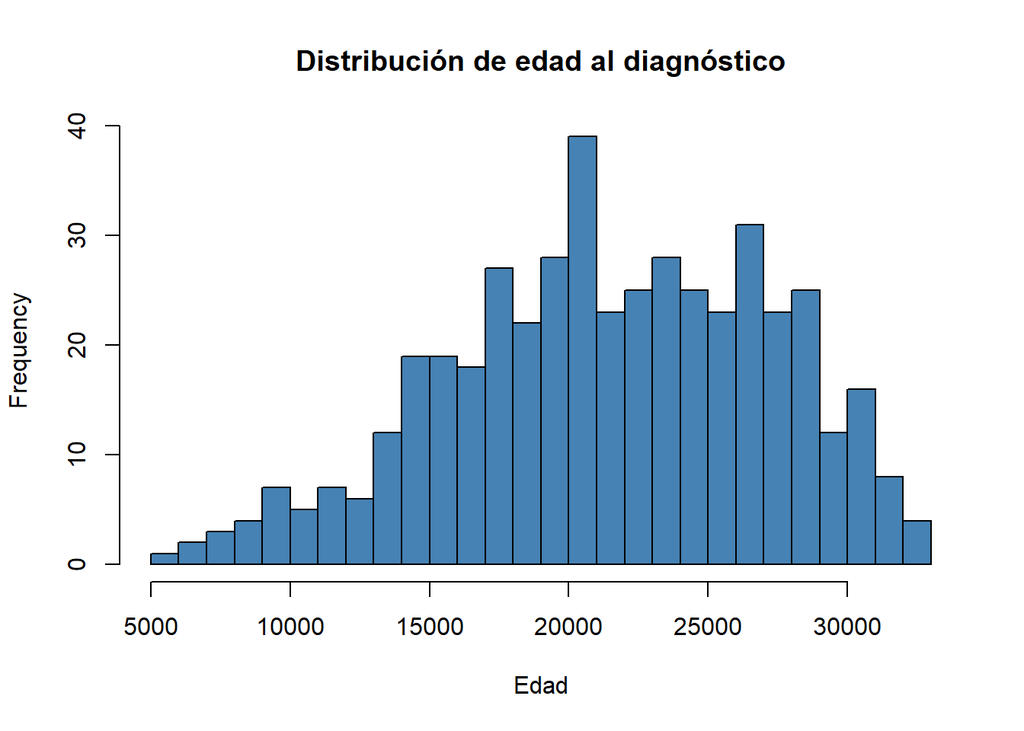

```r
hist(clinical_tcga$age_at_diagnosis,
     breaks = 30,
     col = "steelblue",
     main = "Distribución de edad al diagnóstico",
     xlab = "Edad")
```

Esto añade EDA visual, algo muy valorado en TFM.

**- 6. Exploración de valores faltantes (NA)**

Muy importante en datasets clínicos.

```r
colSums(is.na(clinical_tcga))
```

```
##                                            project
##                                                  0
##                                       submitter_id
##                                                  0
##                                         morphology
##                                                  0
##                                  days_to_diagnosis
##                                                  8
##                                   created_datetime
##                                                470
##                          tissue_or_organ_of_origin
##                                                  0
##                                   age_at_diagnosis
##                                                  8
##                                  primary_diagnosis
##                                                  0
##                            classification_of_tumor
##                                                  0
##                                   updated_datetime
##                                                  0
##                                       diagnosis_id
##                                                  0
##                                        icd_10_code
##                                                352
##                        site_of_resection_or_biopsy
##                                                  0
##                                              state
##                                                  0
##                                    prior_treatment
##                                                  0
##                       diagnosis_is_primary_disease
##                                                  0
##                                        clark_level
##                                                470
##                               ulceration_indicator
##                                                470
##                               sites_of_involvement
##                                                  0
##                                    tumor_of_origin
##                                                470
```

[output cut: 125 more lines]

```
##                                                  0
##       treatments_radiation_route_of_administration
##                                                  0
##              treatments_radiation_number_of_cycles
##                                                  0
##      treatments_radiation_clinical_trial_indicator
##                                                  0
##         treatments_radiation_prescribed_dose_units
##                                                  0
##               treatments_radiation_prescribed_dose
##                                                  0
##                 treatments_radiation_course_number
##                                                  0
##                                bcr_patient_barcode
##                                                  0
```

Para centrarse en variables relevantes:

```r
colSums(is.na(clinical_tcga[, c(
  "age_at_diagnosis",
  "gender",
  "vital_status",
  "days_to_death",
  "days_to_last_follow_up",
  "ajcc_pathologic_stage"
)]))
```

```
##       age_at_diagnosis                 gender           vital_status
##                      8                      0                      0
##          days_to_death days_to_last_follow_up  ajcc_pathologic_stage
##                    249                      8                     52
```

Interpretación típica en la memoria:

Algunas variables clínicas presentan valores faltantes, lo cual es habitual en datasets clínicos retrospectivos.

**- 7. Variables de supervivencia**

Esto es MUY importante para tu TFM.

Exploramos:

```r
summary(clinical_tcga$days_to_death)
```

```
##    Min. 1st Qu.  Median    Mean 3rd Qu.    Max.    NA's
##       0     518    1093    1783    2073   10870     249
```

```r
summary(clinical_tcga$days_to_last_follow_up)
```

```
##    Min. 1st Qu.  Median    Mean 3rd Qu.    Max.    NA's
##    -2.0   484.5  1106.0  1830.5  2363.5 11252.0       8
```

Esto permitirá después construir:

OS_time

OS_event

para análisis de supervivencia.

**-8. Conversión de variables categóricas a factor**

Por ejemplo:

```r
clinical_tcga$gender <- factor(clinical_tcga$gender)
clinical_tcga$vital_status <- factor(clinical_tcga$vital_status)
clinical_tcga$ajcc_pathologic_stage <- factor(clinical_tcga$ajcc_pathologic_stage)
```

Después comprobamos:

```r
class(clinical_tcga$gender)
```

```
## [1] "factor"
```

```r
levels(clinical_tcga$gender)
```

```
## [1] "female" "male"
```

**-9. Resumen descriptivo general**

```r
summary(clinical_tcga)
```

[output not shown]

[output cut: 24908 more lines]

[output not shown]

Esto da:

mínimo

máximo

mediana

cuartiles

Lo que añadiría para que tu EDA sea de nivel TFM

Dos cosas más que quedan muy bien:

**- 10. Distribución de estadio (visual)**

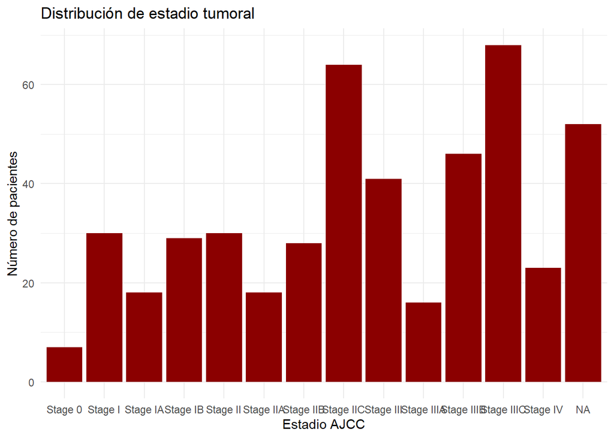

```r
ggplot(clinical_tcga, aes(x = ajcc_pathologic_stage)) +
  geom_bar(fill = "darkred") +
  theme_minimal() +
  labs(
    title = "Distribución de estadio tumoral",
    x = "Estadio AJCC",
    y = "Número de pacientes"
  )
```

**-11. Edad vs estado vital**

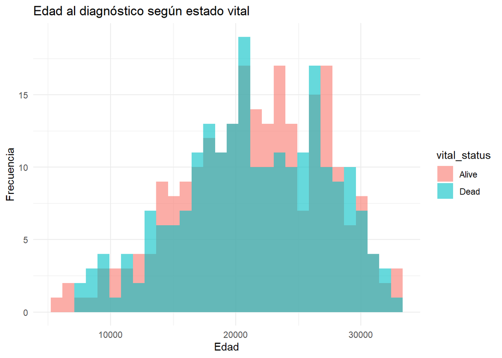

```r
ggplot(clinical_tcga, aes(x = age_at_diagnosis, fill = vital_status)) +
  geom_histogram(position = "identity", alpha = 0.6, bins = 30) +
  theme_minimal() +
  labs(
    title = "Edad al diagnóstico según estado vital",
    x = "Edad",
    y = "Frecuencia"
  )
```

```r
# Ver primeras filas
head(clinical_tcga)
```

```
##     project submitter_id morphology days_to_diagnosis created_datetime
## 1 TCGA-SKCM TCGA-D3-A3CC     8720/3                 0             <NA>
## 2 TCGA-SKCM TCGA-DA-A3F8     8720/3                 0             <NA>
## 3 TCGA-SKCM TCGA-ER-A193     8720/3                 0             <NA>
## 4 TCGA-SKCM TCGA-WE-A8ZO     8720/3                 0             <NA>
## 5 TCGA-SKCM TCGA-FS-A1ZU     8720/3                 0             <NA>
## 6 TCGA-SKCM TCGA-RP-A6K9     8720/3                NA             <NA>
##   tissue_or_organ_of_origin age_at_diagnosis       primary_diagnosis
## 1                 Skin, NOS            25396 Malignant melanoma, NOS
## 2                 Skin, NOS            14327 Malignant melanoma, NOS
## 3                 Skin, NOS            22702 Malignant melanoma, NOS
## 4                 Skin, NOS            26946 Malignant melanoma, NOS
## 5                 Skin, NOS            25856 Malignant melanoma, NOS
## 6                 Skin, NOS               NA Malignant melanoma, NOS
##   classification_of_tumor                 updated_datetime
```

[output cut: 363 more lines]

```r
# Ver estructura general
glimpse(clinical_tcga)
```

```
## Rows: 470
## Columns: 90
## $ project                                            <chr> "TCGA-SKCM", "TCGA-…
## $ submitter_id                                       <chr> "TCGA-D3-A3CC", "TC…
## $ morphology                                         <chr> "8720/3", "8720/3",…
## $ days_to_diagnosis                                  <int> 0, 0, 0, 0, 0, NA, …
## $ created_datetime                                   <chr> NA, NA, NA, NA, NA,…
## $ tissue_or_organ_of_origin                          <chr> "Skin, NOS", "Skin,…
## $ age_at_diagnosis                                   <int> 25396, 14327, 22702…
## $ primary_diagnosis                                  <chr> "Malignant melanoma…
## $ classification_of_tumor                            <chr> "not reported", "pr…
## $ updated_datetime                                   <chr> "2025-01-08T13:20:3…
## $ diagnosis_id                                       <chr> "ec3bb776-9eb6-5f68…
## $ icd_10_code                                        <chr> NA, NA, "C49.0", NA…
## $ site_of_resection_or_biopsy                        <chr> "Not Reported", "No…
```

[output cut: 77 more lines]

```r
# Ver distribución de estado vital
table(clinical_tcga$vital_status, useNA = "ifany")
```

```
##
## Alive  Dead
##   247   223
```

```r
# Ver distribución de estadio
table(clinical_tcga$ajcc_pathologic_stage, useNA = "ifany")
```

```
##
##    Stage 0    Stage I   Stage IA   Stage IB   Stage II  Stage IIA  Stage IIB
##          7         30         18         29         30         18         28
##  Stage IIC  Stage III Stage IIIA Stage IIIB Stage IIIC   Stage IV       <NA>
##         64         41         16         46         68         23         52
```

```r
# Ver cuántos valores faltan hay en variables clave
colSums(is.na(clinical_tcga[, c(
  "submitter_id",
  "age_at_diagnosis",
  "gender",
  "vital_status",
  "days_to_death",
  "days_to_last_follow_up",
  "ajcc_pathologic_stage"
)]))
```

```
##           submitter_id       age_at_diagnosis                 gender
##                      0                      8                      0
##           vital_status          days_to_death days_to_last_follow_up
##                      0                    249                      8
##  ajcc_pathologic_stage
##                     52
```